# Analysis for Coursera DataScience Machine Learning Final Project

Charles

September 12, 2017

## Background

Using devices such as Jawbone Up, Nike FuelBand, and Fitbit it is now possible to collect a large amount of data about personal activity relatively inexpensively. These type of devices are part of the quantified self movement - a group of enthusiasts who take measurements about themselves regularly to improve their health, to find patterns in their behavior, or because they are tech geeks. One thing that people regularly do is quantify how much of a particular activity they do, but they rarely quantify how well they do it. In this project, your goal will be to use data from accelerometers on the belt, forearm, arm, and dumbell of 6 participants. They were asked to perform barbell lifts correctly and incorrectly in 5 different ways. More information is available from the website here: [Link](http://web.archive.org/web/20161224072740/http:/groupware.les.inf.puc-rio.br/har) (see the section on the Weight Lifting Exercise Dataset).

## Executive Summary

This report focuses on building a machine learning model to predict the `classe` variable. Firstly it loads data from internet and cleans data to remove near zero variance variables and NA variables. Then it choses random forest method and set number of trees to be 500 to fit the model. After that the paper predicts using test dataset, estimates the out of sample error and shows the variable importance.

## Set environment and load data

```r
library(caret)
library(ggplot2)
library(dplyr)
library(randomForest)
```

Load the data:

```r
if (!file.exists("./Data")){
        dir.create("./Data")
}
urlTrain <- "https://d396qusza40orc.cloudfront.net/predmachlearn/pml-training.csv"
urlTest <- "https://d396qusza40orc.cloudfront.net/predmachlearn/pml-testing.csv"
download.file(urlTrain, destfile = "./Data/trainFP")
download.file(urlTest, destfile = "./Data/testFP")
training <- read.csv("./Data/trainFP")
testing <- read.csv("./Data/testFP")
```

Have a general idea of the data:

```r
str(training)
```

```
## 'data.frame':    19622 obs. of  160 variables:
##  $ X                       : int  1 2 3 4 5 6 7 8 9 10 ...
##  $ user_name               : Factor w/ 6 levels "adelmo","carlitos",..: 2 2 2 2 2 2 2 2 2 2 ...
##  $ raw_timestamp_part_1    : int  1323084231 1323084231 1323084231 1323084232 1323084232 1323084232 1323084232 1323084232 1323084232 1323084232 ...
##  $ raw_timestamp_part_2    : int  788290 808298 820366 120339 196328 304277 368296 440390 484323 484434 ...
##  $ cvtd_timestamp          : Factor w/ 20 levels "02/12/2011 13:32",..: 9 9 9 9 9 9 9 9 9 9 ...
##  $ new_window              : Factor w/ 2 levels "no","yes": 1 1 1 1 1 1 1 1 1 1 ...
##  $ num_window              : int  11 11 11 12 12 12 12 12 12 12 ...
##  $ roll_belt               : num  1.41 1.41 1.42 1.48 1.48 1.45 1.42 1.42 1.43 1.45 ...
##  $ pitch_belt              : num  8.07 8.07 8.07 8.05 8.07 8.06 8.09 8.13 8.16 8.17 ...
##  $ yaw_belt                : num  -94.4 -94.4 -94.4 -94.4 -94.4 -94.4 -94.4 -94.4 -94.4 -94.4 ...
##  $ total_accel_belt        : int  3 3 3 3 3 3 3 3 3 3 ...
##  $ kurtosis_roll_belt      : Factor w/ 397 levels "","-0.016850",..: 1 1 1 1 1 1 1 1 1 1 ...
##  $ kurtosis_picth_belt     : Factor w/ 317 levels "","-0.021887",..: 1 1 1 1 1 1 1 1 1 1 ...
##  $ kurtosis_yaw_belt       : Factor w/ 2 levels "","#DIV/0!": 1 1 1 1 1 1 1 1 1 1 ...
```

[output cut: 86 more lines]

As we can see above, the training dataset has too many variables and lots of them are NA. So the first thing to do is to clean the data.

## Clean the data

Firstly remove the near zero variance variables that are not useful for our model:

```r
near0Var <- nearZeroVar(training)
training <- training[,-near0Var]
dim(training)
```

```
## [1] 19622   100
```

Then remove the variables that are NAs and empty:

```r
processData <- function(data){
        indexKeep <- !sapply(data, function(x) any(is.na(x)))
        data <- data[,indexKeep]
        indexKeep <- !sapply(data, function(x) any(x == ""))
        data <- data[,indexKeep]
        colNames <- c("X", "user_name", "raw_timestamp_part_1", "raw_timestamp_part_2",
                      "cvtd_timestamp", "new_window", "num_window")
        indexCol <- which(names(data) %in% colNames)
        data <- data[,-indexCol]
        return(data)
}
training <- processData(training)
dim(training)
```

```
## [1] 19622    53
```

```r
table(complete.cases(training))
```

```
##
##  TRUE
## 19622
```

As we can see, we removed all NA variables and reduce the number of variables to 53. Then do the same things to test dataset.

```r
near0Var2 <- nearZeroVar(testing)
testing <- testing[,-near0Var2]
testing <- processData(testing)
dim(testing)
```

```
## [1] 20 53
```

## Fit machine learning model

### Data partition

Firstly we do data partition:

```r
set.seed(20170917)
inTrain <- createDataPartition(training$classe, p=0.8, list = FALSE)
newTraining <- training[inTrain,]
newTesting <- training[-inTrain,]
dim(newTraining)
```

```
## [1] 15699    53
```

```r
dim(newTesting)
```

```
## [1] 3923   53
```

### Select model

The goal of the model is to predict `classe` varibale, which is a factor. So we use the random forest model. The 500 number of trees seems to be a good trade off. Fit the model:

```r
modFitRF <- randomForest(classe ~., data = newTraining, ntree = 500)
```

Then predict the result using test dataset:

```r
predRF <- predict(modFitRF, newTesting)
conMatrix1 <- confusionMatrix(predRF, newTesting$classe)
conMatrix1
```

```
## Confusion Matrix and Statistics
##
##           Reference
## Prediction    A    B    C    D    E
##          A 1115    5    0    0    0
##          B    0  753    2    0    0
##          C    0    1  682    3    1
##          D    0    0    0  640    0
##          E    1    0    0    0  720
##
## Overall Statistics
##
##                Accuracy : 0.9967
##                  95% CI : (0.9943, 0.9982)
##     No Information Rate : 0.2845
##     P-Value [Acc > NIR] : < 2.2e-16
##
##                   Kappa : 0.9958
##  Mcnemar's Test P-Value : NA
##
## Statistics by Class:
##
##                      Class: A Class: B Class: C Class: D Class: E
## Sensitivity            0.9991   0.9921   0.9971   0.9953   0.9986
## Specificity            0.9982   0.9994   0.9985   1.0000   0.9997
## Pos Pred Value         0.9955   0.9974   0.9927   1.0000   0.9986
## Neg Pred Value         0.9996   0.9981   0.9994   0.9991   0.9997
## Prevalence             0.2845   0.1935   0.1744   0.1639   0.1838
## Detection Rate         0.2842   0.1919   0.1738   0.1631   0.1835
## Detection Prevalence   0.2855   0.1925   0.1751   0.1631   0.1838
## Balanced Accuracy      0.9987   0.9957   0.9978   0.9977   0.9992
```

### Out of sample error

The estimation of out-of-sample-error should be one minus the test set accuracy:

```r
OOSE <- 1 - conMatrix1$overall[1]
OOSE
```

```
##   Accuracy
## 0.00331379
```

As we can see the out-of-sample-error is 0.0033138.

### Variable importance

```r
varImp(modFitRF)
```

```
##                        Overall
## roll_belt            977.02075
## pitch_belt           564.75518
## yaw_belt             743.55821
## total_accel_belt     179.71146
## gyros_belt_x          77.73320
## gyros_belt_y          93.09288
## gyros_belt_z         238.46171
## accel_belt_x          92.73733
## accel_belt_y          98.86323
## accel_belt_z         331.90754
## magnet_belt_x        203.66311
## magnet_belt_y        298.18499
## magnet_belt_z        322.57743
## roll_arm             251.65313
## pitch_arm            139.08009
## yaw_arm              193.28151
## total_accel_arm       81.27514
## gyros_arm_x          108.10662
## gyros_arm_y          104.77960
## gyros_arm_z           48.31357
## accel_arm_x          188.40914
## accel_arm_y          118.78885
## accel_arm_z          103.68645
## magnet_arm_x         213.91301
## magnet_arm_y         175.17543
## magnet_arm_z         141.87785
## roll_dumbbell        333.36584
## pitch_dumbbell       139.90097
## yaw_dumbbell         205.45063
## total_accel_dumbbell 206.91190
## gyros_dumbbell_x     106.28454
## gyros_dumbbell_y     198.56801
## gyros_dumbbell_z      66.60681
## accel_dumbbell_x     200.74871
## accel_dumbbell_y     352.42665
## accel_dumbbell_z     267.02157
## magnet_dumbbell_x    369.95797
## magnet_dumbbell_y    536.29439
## magnet_dumbbell_z    603.46430
## roll_forearm         486.52059
## pitch_forearm        651.44932
## yaw_forearm          139.68252
## total_accel_forearm   95.86603
## gyros_forearm_x       60.06514
## gyros_forearm_y      103.59643
## gyros_forearm_z       67.72791
## accel_forearm_x      255.99917
## accel_forearm_y      111.26565
## accel_forearm_z      196.00351
## magnet_forearm_x     172.85107
## magnet_forearm_y     166.01529
## magnet_forearm_z     226.98222
```

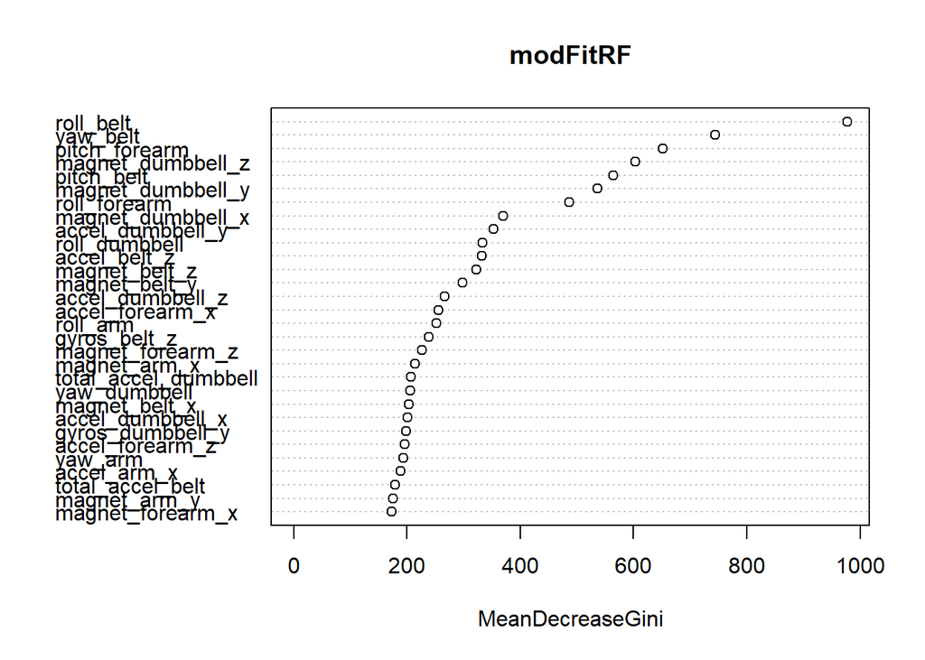

```r
varImpPlot(modFitRF)
```

## System information

```r
Sys.info()[1:2]
```

```
##   sysname   release
## "Windows"  "10 x64"
```

```r
R.version.string
```

```
## [1] "R version 3.3.3 (2017-03-06)"
```